# Tris et rangs

## Définition

On définit le problème du tri comme:

Entrée: une séquence de valeurs $a_1, a_2, ..., a_n$

Sortie: une **permutation** $\sigma$ (un réarrangement) telle que la séquence $$a_{\sigma(1)}, a_{\sigma(2)}, ..., a_{ \sigma(n)}$$ soit **ordonnée**.

## Clé de tri

On parle de **clé de tri** pour désigner l'élément sur lequel l'ordre est mis en place.

- Type de clé usuelles: nombre, chaine, liste
- Clé définie par l'utilisateur. Ex. pour une chaine
  - ordre lexicographique (par défaut)
  - nombre de caractères pour une chaine
  - nombre de consonnes puis nombre de voyelles
  - mois de l'année: 'Janvier' < 'Février'
- Clé simple dans une structure plus complexe.

  Ex.: Tuple (JJ, MM, YYYY)

Le langage de programmation fait donc des choix de clés par défaut.

Il revient au programmeur de les adapter si besoin est, et de définir sa propre de comparaison.

## Classification des algorithmes de tri

Définition: Tri en place ou non

Un algorithme de tri est dit **en place** lorsque jamais plus d'un *nombre constant* d'éléments est stocké hors du tableau quelque soit sa taille.

Définition: Tri stable

Un algorithme de tri est dit **stable** lorsque l'ordre des éléments ayant une *clé identique* est maintenu.

On peut rendre stable un algorithme de tri en introduisant une clé secondaire.

Définition: Tri par comparaison ou non (voir TP)

- Un algorithme de tri peut utiliser des comparaisons "<"
- ou non...

Définition: Tri incrémental ou non

- Un algorithme de tri est **incrémental** si il est succeptible de traiter les données une par une sans disposer du tableau en entier.

## Tri par sélection

[figure not shown]

### Analyse du Tri par sélection

*Terminaison*: OK

*Correction de l'algorithme* par invariant:

*Avant*:

- T[1..i-1] est trié
- Pour tout j=i..n, T[j] >= T[i-1]

*Après*:

- T[1..i] est trié
- Pour tout j=i+1..n, T[j] $\geq$ T[i]

*A la fin*:

- T[1..n-1] est trié
- T[n] $\geq$ T[n-1]

=> T est donc trié !

**Efficience de l'algorithme**

Nombre d'échanges ?

Pour i fixé, 1 échange.

Nombre total d'**échanges**: n-1

Nombre de comparaisons ?

Pour i fixé, n-i comparaisons.

- i = 1 -> n - 1 comparaisons
- i = 2 -> n - 2 comparaisons
- ...
- i = n - 2 -> 2 comparaisons
- i = n - 1 -> 1 comparaison

Nombre total de **comparaisons**: $$1+2+3+...+(n-2)+(n-1) = \frac{n*(n-1)}{2} \sim n^2$$

### Implémentation en Python

```python
def tri_selection(T):
    n = len(T)
    for i in range(0, n-1):
        imin = i
        for j in range(i+1, n):
            if T[j] < T[imin]:
                imin = j
        T[i], T[imin] = T[imin], T[i]
    return T
```

```python
import random

def estTrie(L, deb=0, fin=None):
    if fin is None:
        fin = len(L)
    for i in range(1, fin):
        if L[i-1] > L[i] :
            return False
    return True

def tableau(n, min=0, max=100):
    return [random.randint(min, max) for _ in range(n)]
```

```python
# Vérification rapide qui n'est pas une preuve de correction
T = [4, 6, -4, 2, 5, 3]
T2 = tri_selection(T)
print(f'{T} est trié : {estTrie(T)}')
```

```
[-4, 2, 3, 4, 5, 6] est trié : True
```

```python
import matplotlib.pyplot as plt
from time import time

tps_select = []
N = list(range(10, 5000, 50))
for n in N:
    T = tableau(n)
    debut = time()
    _ = tri_selection(T)
    tps_select.append(time() - debut)
```

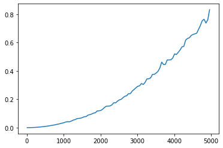

```python
plt.plot(N, tps_select)
plt.show()
```

## Tri par insertion

[figure not shown]

### Tri par insertion (démo)

[source: Tri par insertion (Wikipédia)](https://fr.wikipedia.org/wiki/Tri_par_insertion)

### Caractéristiques: Tri par insertion

Il est:

- en place
- stable (car inf. strict)
- par comparaison
- incrémental

*Terminaison de l'algorithme*: OK

*Correction de l'algorithme* par invariant:

- *Avant*: T[1..i-1] est trié
- *Après*: T[1..i] est trié
- *A la fin (i = n)*, T est donc trié !

*Efficience de l'algorithme*

Le nombre de comparaisons est proportionnel au nombre d'échanges.

- Pour i fixé, on distingue plusieurs cas:
  - 2 comparaisons si T[i] $\geq$ T[i-1]
  - 2*i comparaisons si T[i] = clé $<$ T[j] pour tout j=1..i-1.
  - i= 2*i/2 comparaisons en moyenne

Nombre total de **comparaisons**: $$2n \leq nbComp(n) \leq 2 n^2$$

### Implémentation en Python

```python
def tri_insertion(T):
    n = len(T)
    for i in range(1, n):
        cle = T[i]
        j = i - 1
        while j >= 0 and T[j] > cle:
            T[j+1] = T[j]
            j = j - 1
        T[j+1] = cle
    return T
```

```python
# Vérification rapide qui n'est pas une preuve de correction
T = [4, 6, -4, 2, 5, 3]
T2 = tri_insertion(T)
print(f'{T} est trié : {estTrie(T)}')
```

```
[-4, 2, 3, 4, 5, 6] est trié : True
```

```python
import matplotlib.pyplot as plt
from time import time

tps_insertion = []
for n in N:
    T = tableau(n)
    debut = time()
    _ = tri_insertion(T)
    tps_insertion.append(time() - debut)
```

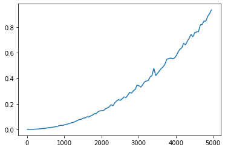

```python
plt.plot(N, tps_insertion)
plt.show()
```

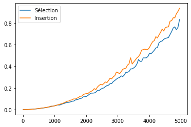

```python
plt.plot(N, tps_select, label="Sélection")
plt.plot(N, tps_insertion, label="Insertion")
plt.legend()
plt.show()
```

```python
T = tableau(5000)
T2 = T[:]
T_trie = tri_selection(T)
T_trie_inv = T_trie[::-1]    # T_trie_inv = reversed(T_trie)
deb = time(); _ = tri_insertion(T_trie); print(f"Meilleur des cas: {time() - deb}")
deb = time(); _ = tri_insertion(T2); print(f"Un cas: {time() - deb}")
deb = time(); _ = tri_insertion(T_trie_inv); print(f"Pire des cas: {time() - deb}")
```

```
Meilleur des cas: 0.0008358955383300781
Un cas: 0.9388899803161621
Pire des cas: 1.8763608932495117
```

```python
T = tableau(5000)
T2 = T[:]
T_trie = tri_selection(T)
T_trie_inv = T_trie[::-1]    # T_trie_inv = reversed(T_trie)
deb = time(); _ = tri_selection(T_trie); print(f"Cas 1: {time() - deb}")
deb = time(); _ = tri_selection(T2); print(f"Cas 2: {time() - deb}")
deb = time(); _ = tri_selection(T_trie_inv); print(f"Cas 3: {time() - deb}")
```

```
Cas 1: 0.8015439510345459
Cas 2: 0.7993617057800293
Cas 3: 0.7835958003997803
```

## Dictionnaire en compréhension

```python
import string

ch = string.ascii_lowercase
L = [i for i in range(len(ch))]

D = {k:v+1 for k, v in zip(ch, L)}
print(D)
```

```
{'a': 1, 'b': 2, 'c': 3, 'd': 4, 'e': 5, 'f': 6, 'g': 7, 'h': 8, 'i': 9, 'j': 10, 'k': 11, 'l': 12, 'm': 13, 'n': 14, 'o': 15, 'p': 16, 'q': 17, 'r': 18, 's': 19, 't': 20, 'u': 21, 'v': 22, 'w': 23, 'x': 24, 'y': 25, 'z': 26}
```